# Introduction to R: Week 4 Solutions

FACS example

Maria Doyle

23 May 2019

## Challenge

You’ve run a FACS experiment and you need to calculate percentages of the cell types you’ve measured and visualise the data. You can do it in Excel but it’s becoming very tedious and error-prone because you have several experiments you need to analyse.

Let’s try to use what we’ve learnt about R and the tidyverse to analyse and visualise the data.

- Read in the Excel file called facs_example_data.xlsx, save it as an object called facs. Hint: use library(readxl) and Google to find the function to read in an excel file.

```r
library(tidyverse)
library(readxl)
facs <- read_excel("/training/r-intro-tidyverse/data/facs_example_data.xlsx")
```

```
-
/
```

- Remove the rows containing the test Samples (Test-1, Test-2 and Test-3). Hint: use filter and !str_detect (! means not)

```r
facs <- filter(facs, !str_detect(Sample, "Test"))
```

- Add a column called Group containing a value for whether the Sample is Isotype, PBS or Treatment. Hint: use case_when and str_detect

```r
facs <- mutate(facs, Group=case_when(
  str_detect(Sample, "PBS")  ~ "PBS",
  str_detect(Sample, "Isotype")  ~ "Isotype",
  str_detect(Sample, "Treatment")  ~ "Treatment"
))
```

- Add a column called “%CD4+ T” that contains the CD4T column value as a percent of the T_Cells column for each sample.Note you will need to quote the name of the column as it contains a symbol (%) and a space.

```r
facs <- mutate(facs, "%CD4+ T" = CD4T / T_Cells * 100)
```

- Add more columns with the Column Name below, containing values that are calculations of cell percentages from the named columns e.g. “%CD8+ T” is the CD8T column as a percent of the T_Cells column.

Column Name Value “%CD8+ T” CD8T as percent of T_Cells “%Treg” Treg as percent of CD4T “%Th” Th as percent of CD4T “%B” B as percent of CD45.1 “%NK” NK as percent of CD45.1

```r
facs <- mutate(facs,
               "%CD8+ T" = CD8T / T_Cells * 100,
               "%Treg" = Treg / CD4T * 100,
               "%Th" = Th / CD4T * 100,
               "%B" = B / CD45.1 * 100,
               "%NK" = NK / CD45.1 * 100)
```

- Make jitter plots of the values for the groups. Hints:
1. First convert values to long format with gather, call the key column Cell and the value column Value.
2. Then make jitter plots with Group on the x axis and Value on the y axis.
3. Facet by the Cell column to get plots for each cell percentage

These steps are shown below.

1. First convert values to long format with gather, call the key column Cell and the value column Value.

```r
facs <- gather(facs, key=Cell, value=Value, starts_with("%"))
```

2. Then make jitter plots with Group on the x axis and Value on the y axis.

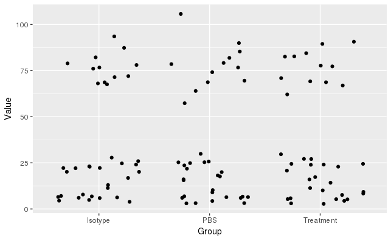

```r
ggplot(facs, aes(x=Group, y=Value)) +
  geom_jitter()
```

3. Facet by the Cell column to get plots for each cell percentage

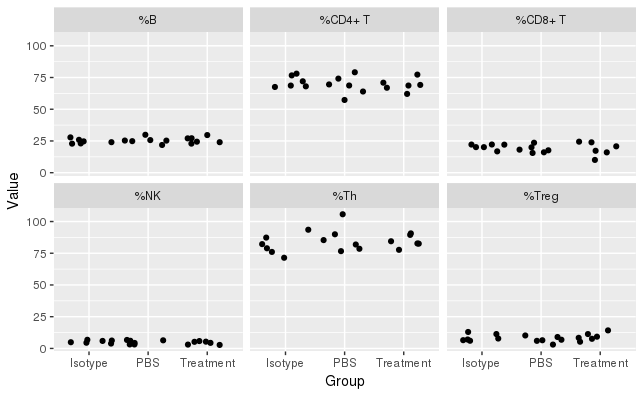

```r
ggplot(facs, aes(x=Group, y=Value)) +
  geom_jitter() +
  facet_wrap(~Cell)
```

- Colour by sample. Bonus if you use colour-blind friendly colours. Hint: Google

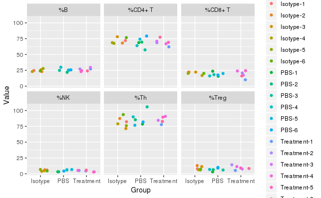

```r
ggplot(facs, aes(x=Group, y=Value, colour=Sample)) +
  geom_jitter() +
  facet_wrap(~Cell)
```

- Change the plot to colour the groups.

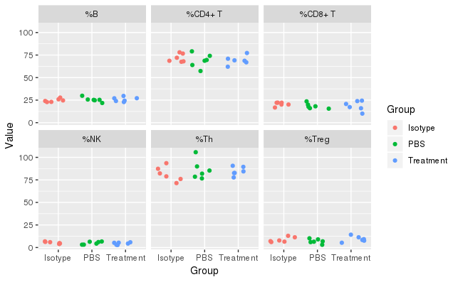

```r
ggplot(facs, aes(x=Group, y=Value, colour=Group)) +
  geom_jitter() +
  facet_wrap(~Cell)
```

- Order the groups along the x axis (and legend) as PBS, Isotype, Treatment. Hint: use factor and levels

```r
group_order <-  c("PBS", "Isotype", "Treatment")
facs <- mutate(facs, Group_f=factor(Group, levels=group_order))
```

- Order the jitter plots as “%CD4+ T”, “%CD8+ T”, “%Treg”, “%Th”, “%NK”, “%B”. Hint: use factor and levels

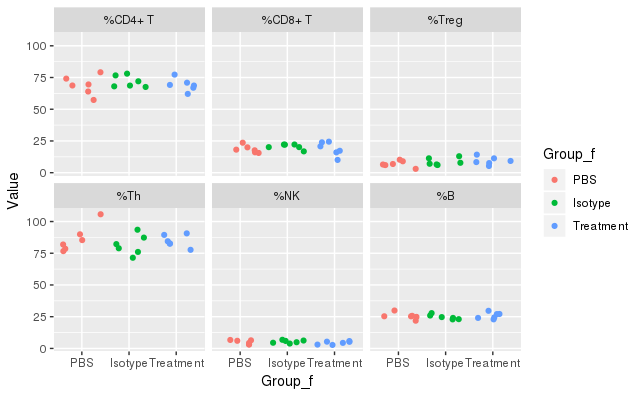

```r
cell_order <-  c("%CD4+ T", "%CD8+ T", "%Treg", "%Th", "%NK", "%B")
facs <- mutate(facs, Cell_f=factor(Cell, levels=cell_order))
ggplot(facs, aes(x=Group_f, y=Value, colour=Group_f)) +
  geom_jitter() +
  facet_wrap(~Cell_f)
```

Note: saving from here on as p to make easier to see the line they need to add

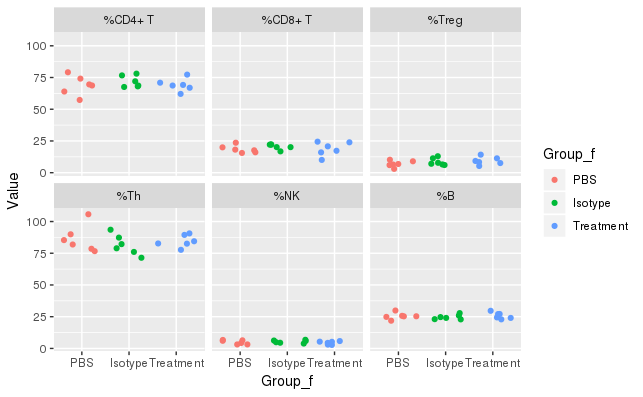

```r
p <- ggplot(facs, aes(x=Group_f, y=Value, colour=Group_f)) +
  geom_jitter() +
  facet_wrap(~Cell_f)
p
```

- Change the X axis label to Condition

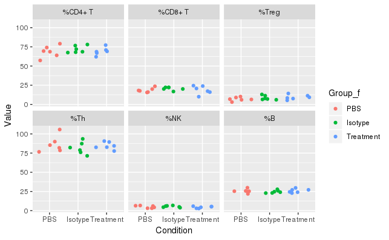

```r
p <- p + labs(x="Condition")
p
```

- Change the Y axis label to Percentage

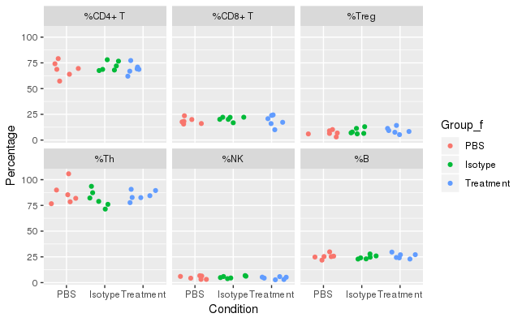

```r
p <- p + labs(y="Percentage")
p
```

- Remove the grey background. Use any theme e.g. theme_bw or theme_minimal

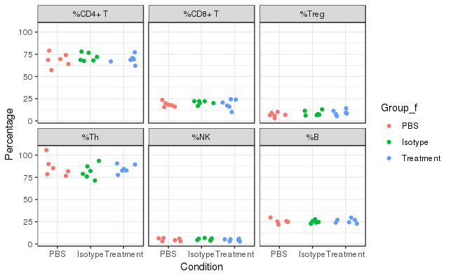

```r
p <- p + theme_bw()
p
```

- Make the x axis labels vertical

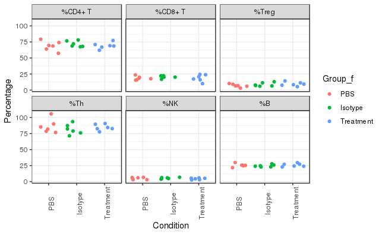

```r
p <- p + theme(axis.text.x = element_text(angle = 90))
p
```

- Remove the legend title (we didn’t cover this they’ll need to Google)

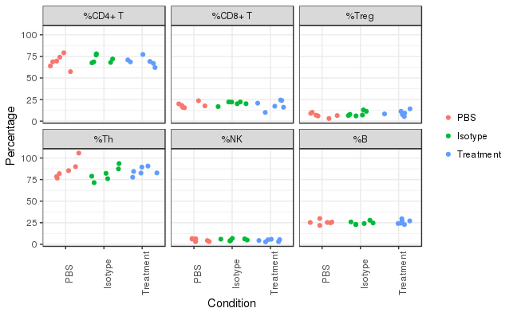

```r
p <- p + theme(legend.title=element_blank())
p
```

- Add a title called “My FACS plots”

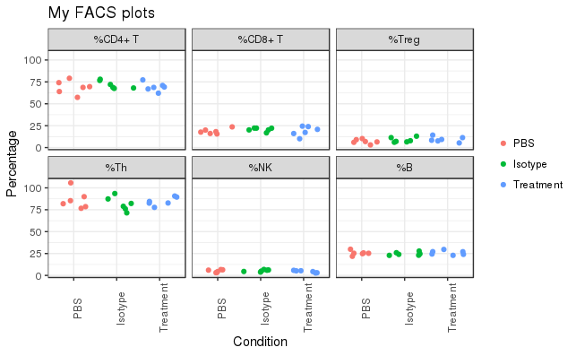

```r
p <- p + labs(title="My FACS plots")
p
```

- Centre the title

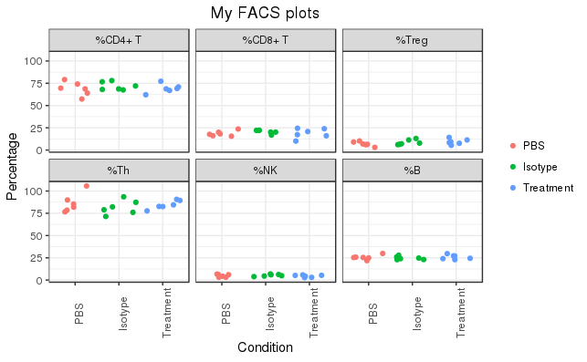

```r
p <- p + theme(plot.title = element_text(hjust = 0.5))
p
```

```r
png("my_facs_plots.png")
p
dev.off()
```

- Save the table used to make the plot as a file (i.e. containing the % columns) as a tab-separated file called “facs_analysis.tsv”. Hint: see the write_tsv function.

```r
write_tsv(facs, "facs_analysis.tsv")
```

- Read in the FACS file from a second experiment that uses the same markers and number of samples. Make a pdf of plots similer to the first experiment. Save it as my_facs_plot_expt2.pdf.

They should be able to run the code they’ve already written with minimal changes, just change the name of the file they’ve read in and the output pdf name. This is to show how they can reuse their code. The entire code for this is below.

```r
# read in the data
facs <- read_excel("/training/r-intro-tidyverse/data/facs_example_data2.xlsx")
```

```
-
/
```

```r
# remove the test samples
facs <- filter(facs, !str_detect(Sample, "Test"))
# add a column for the groups
facs <- mutate(facs, Group=case_when(
  str_detect(Sample, "PBS")  ~ "PBS",
  str_detect(Sample, "Isotype")  ~ "Isotype",
  str_detect(Sample, "Treatment")  ~ "Treatment"
))
# add columns for the cell percentages
facs <- mutate(facs,
               "%CD4+ T" = CD4T / T_Cells * 100,
               "%CD8+ T" = CD8T / T_Cells * 100,
               "%Treg" = Treg / CD4T * 100,
               "%Th" = Th / CD4T * 100,
               "%B" = B / CD45.1 * 100,
               "%NK" = NK / CD45.1 * 100)
# convert from wide to long format
facs <- gather(facs, key=Cell, value=Value, starts_with("%"))
# order the groups
group_order <-  c("PBS", "Isotype", "Treatment")
facs <- mutate(facs, Group_f=factor(Group, levels=group_order))
# order the markers
cell_order <-  c("%CD4+ T", "%CD8+ T", "%Treg", "%Th", "%NK", "%B")
facs <- mutate(facs, Cell_f=factor(Cell, levels=cell_order))
# make a pdf of the plots
pdf("my_facs_plot_expt2.pdf")
ggplot(facs, aes(x=Group_f, y=Value, colour=Group_f)) +
  geom_jitter() +
  facet_wrap(~Cell_f) +
  labs(x="Condition") +
  labs(y="Percentage") +
  theme_bw() +
  theme(axis.text.x = element_text(angle = 90)) +
  theme(legend.title=element_blank()) +
  labs(title="My FACS plots") +
  theme(plot.title = element_text(hjust = 0.5))
dev.off()
```